# Metrics of Aging - Phenotypic Aging in BLSA

Perry Kuo, Luigi Ferrucci, Jennifer Schrack, Michelle Shardell, Morgan Levine

Oct 4, 2018

The format is adopted from course led by [Dr. Stephanie Hicks](https://jhu-advdatasci.github.io/2018/)

# Motivation

With the advent of public health and medical care, the life expetancy has increased over past half century. The society is aging, and there are more and more researchers trying to understand the underlying mechanism why human age, and the potential modifiable facorts to decelerate the aging process. To achieve these goals, some researchers proposed some metrics to capture the functional aging, such as frailty index, and further investigate the relationship between functional aging and disability/mortality. With the hypothesis that functions are especially important for older people and applying potential approaches to improve functions may maximize human’s quality of life and prolong longevity, functional aging has been one of the main foci in geriatric research over past two decades. Consequently, it is of vital importance to understand the drivers of functional declines, which can be potentially measured by changes of phenotypes.

To understand the biological mechanism of aging, several metrics of biological age, such as epigenetic clock, have been proposed. Among these proposed metrics, most of them utilized the data available, and leverage on the dimension reduction tools and choose the statitical model fit the mortality the best as biological age. With lack of a more conceptual and mechanistic framework, these metrics may be useful for mortality or cormorbitidy prediction, but may not be able to capture the earlier change of aging.

Thus, we propose a temporal heirarchy framework for metrics of aging, in which phenotypes serve as the bridge between underlying biological drivers of aging and the functional decline we observe. Earlier this year, the concept has been described by [Dr. Luigi Ferrucci et al](https://www.ahajournals.org/doi/10.1161/CIRCRESAHA.118.312816), and is shown as following:

[figure not shown]

with proposed measures as following:

[figure not shown]

With an attempt to understand these temporal heirarchy of aging, in Baltimore Loungitudinal Study of Aging (BLSA), not only the functions, but also the proposed phenotypes were measured within participants with relatively health status when recruited, for the purpose of diminishing the effect of diseases as more as possible.

In this paper, we try to understand:

*1. Are the proposed phenotypes appropriate in terms of functional decline?*  
*2. Do the proposed phenotyes within the same domain capture similar properties? And do the prosposed phenotyeps accross different domians capture the construct of aging?*

# Are the proposed phenotypes appropriate?

This is the other way to visualize our conceptual domains, with proposed variables.

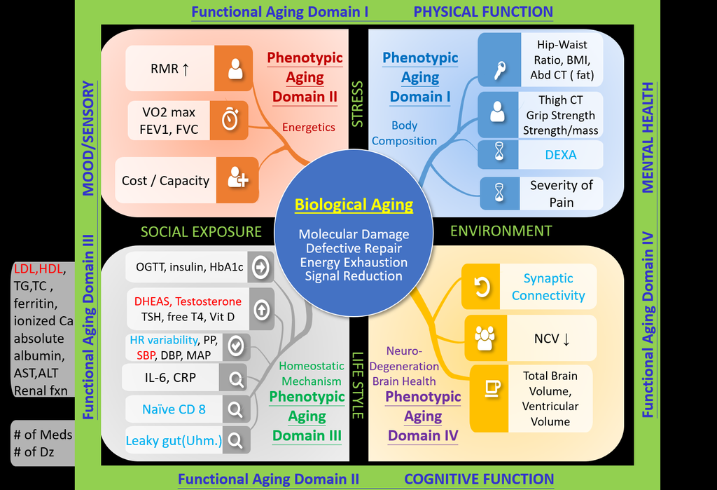

The proposed measures have been earlier described in one paper published on [Circulatoin Research](https://www.ahajournals.org/doi/10.1161/CIRCRESAHA.118.312816).

These include: * Energetics * Body composition * Homeostaic mechanism * Brain health

## Brain health

# Do the proposed phenotyes within the same domain capture similar properties?

# Do the prosposed phenotypes accross different domians capture the construct of aging?

- The is an theory-based structure for the construct of phenotypic aging.
- The goal is to demonstrate what we are going to do. Thus, let us go through them, and come up with refined model.

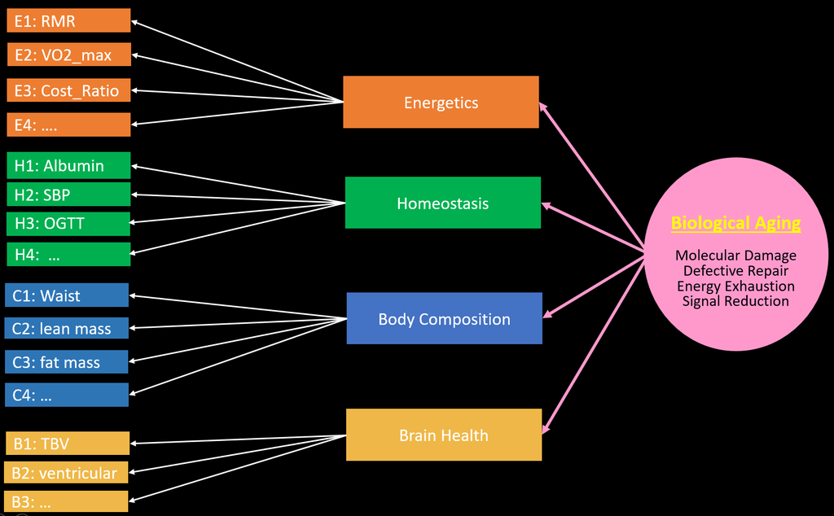

## Create the dataset including 4 damians

Note: This is not complete list yet.

- Energetics:

| Name in factor analysis | Variable | Explanation/Note |
| --- | --- | --- |
| E1 | RMR | Resting metabolic Rate |
| E2 | VO2_max | Max VO2 |
| E3 | cost_ratio | cost-capacity ratio |
| E4,E5,.. | To be added… | Ex: pulmonary function |

- Take a look at the data.

  | idno | visit | rmr_kcal | vo2_max | cost_ratio |
  | --- | --- | --- | --- | --- |
  | 99 | 24 | 1770.765 | NA | NA |
  | 113 | 25 | NA | 21.1 | NA |
  | 113 | 26 | 1537.080 | 20.6 | 0.9500501 |
  | 113 | 27 | 1934.127 | NA | 0.9503537 |
  | 113 | 28 | 1454.075 | 19.3 | 0.9442118 |
  | 113 | 29 | 1473.964 | 18.7 | 0.8755534 |
  | 113 | 30 | 1395.489 | NA | NA |
  | 164 | 22 | NA | 15.4 | NA |
  | 164 | 23 | 1393.141 | 16.7 | NA |
  | 166 | 6 | NA | 28.9 | NA |

- Body composition:

| Name in factor analysis | Variable | Explanation/Note |
| --- | --- | --- |
| C1 | waist | sex,height-adjusted (From DEXA) |
| C2 | lean mass | sex,height-adjusted (From DEXA) |
| C3 | fat mass | sex,height-adjusted (From DEXA) |
| C4 | thigh | sex,height-adjusted (From CT muscle area) |
| C5,.. | To be added… | Ex: severity of pain |

- Take a look at the data.

  | idno | visit | fatmass | leanmass | waist | thigh | fatmass_maleht | leanmass_maleht | thigh_maleht | waist_maleht |
  | --- | --- | --- | --- | --- | --- | --- | --- | --- | --- |
  | 88 | 22 | 50465.73 | 61267.24 | 125.7 | 12350.082 | 19876.624 | -1989.69801 | -14021.56 | 25.8398894 |
  | 88 | 23 | 55080.72 | 68564.64 | 121.0 | 12286.186 | 24697.828 | 5644.00241 | -13948.63 | 21.2570748 |
  | 88 | 24 | 53931.09 | 62593.62 | 122.0 | 11492.729 | 23720.040 | -46.75846 | -13882.93 | 22.3547294 |
  | 95 | 11 | 20332.66 | 53846.10 | 97.7 | 11375.427 | -5307.298 | -1339.51494 | -12186.27 | 0.6523392 |
  | 113 | 29 | 17892.34 | 53731.75 | 83.1 | 9138.107 | -12937.356 | -9917.54241 | -14154.74 | -16.8968269 |
  | 164 | 23 | 44562.27 | 58544.03 | 114.8 | 10787.010 | 18234.937 | 2237.39463 | -12427.96 | 17.3617211 |
  | 164 | 24 | 46875.39 | 60125.75 | 114.0 | 10877.609 | 20616.789 | 3931.21747 | -12402.88 | 16.6007829 |
  | 166 | 7 | 23629.76 | 51952.65 | 98.6 | 10732.651 | -7234.306 | -11752.69581 | -14152.18 | -1.4163578 |
  | 166 | 8 | 20474.12 | 54655.97 | 92.0 | 10492.325 | -10114.988 | -8600.96881 | -14055.26 | -7.8601106 |
  | 180 | 28 | 21691.97 | 50867.10 | 95.3 | 9007.454 | -6216.346 | -8017.87425 | -13042.68 | -3.0367003 |

- Homeostasis:

| Name in factor analysis | Variable | Explanation/Note |
| --- | --- | --- |
| H1 | Albumin | albumin (g/dL) |
| H2 | SBP | systolic blood pressure (mmHg) |
| H3 | OGTT-IR | insulin-resistence = fasting plasma glucose (mg/dL) × fasting insulin (mU/L) divided by 405, defined by [HOMA-IR](https://www.ncbi.nlm.nih.gov/pubmed/3899825/) |
| H4 | OGTT-ISMI | [Insulin sensitivity - Matsuda index](https://www.ncbi.nlm.nih.gov/pubmed/10480510/) = 10,000/ square root of [(fasting glucose × fasting insulin) × (mean glucose × mean insulin during OGTT)]) |
| H5 | OGTT-ISRMI | [Insulin sensitivity - Reduced Matsuda index](https://www.ncbi.nlm.nih.gov/pubmed/20587713/) = 10,000/ square root of [(fasting glucose × fasting insulin) × (glucose at 120 min × insulin at 120 min)] |
| H7 | 24Ccr | 24 hr CCr (many missing due to 24hr urine) |
| H8 | HDL | HDL (mg/dL) |
| H9 | LDL | LDL (mg/dL) |
| H10 | log(IL-6) | IL-6 (il6<50 & il6 > 0) |
| H11 | log(CRP) | C-reactive Protein (crp<30 & crp > 0) |
| H12 | RDW | RDW |
| H12,.. | To be added… | Ex: testosterone, Vit D, pwv, pr, … |

- Take a look at the data.

  | idno | visit | albumin | ldl | hdl | il6 | crp | rdw | creat | urine24hrcreat | ccr24hr | logcrp | logil6 | sbp | homair | ismi | isrmi |
  | --- | --- | --- | --- | --- | --- | --- | --- | --- | --- | --- | --- | --- | --- | --- | --- | --- |
  | 87 | 18 | 3.7 | 142 | 69.7 | 4.4760 | 2.590000 | 13.5 | 0.90 | NA | NA | 1.2781522 | 1.700375 | 154 | NA | NA | NA |
  | 88 | 22 | 4.0 | 84 | 31.0 | 3.6250 | 3.285476 | 14.1 | 1.60 | NA | NA | 1.4552316 | 1.531476 | 139 | NA | NA | NA |
  | 88 | 24 | 3.5 | 83 | 30.0 | 6.3000 | 9.129473 | 15.8 | 1.72 | NA | NA | 2.3154493 | 1.987874 | 99 | 9.247163 | 0.920630 | 0.7161769 |
  | 95 | 10 | 4.1 | 111 | 65.0 | 4.0933 | 1.110000 | 13.7 | 0.90 | NA | NA | 0.7466879 | 1.627926 | 126 | NA | NA | NA |
  | 95 | 11 | 4.1 | 113 | 57.0 | 6.9949 | 2.440000 | 15.0 | 1.00 | NA | NA | 1.2354715 | 2.078804 | 135 | NA | NA | NA |
  | 95 | 12 | 4.3 | 100 | 47.0 | 7.8250 | 5.549392 | 15.9 | 0.90 | NA | NA | 1.8793722 | 2.177589 | 120 | NA | NA | NA |
  | 99 | 22 | 4.1 | 128 | 66.0 | 4.8601 | 1.370000 | 14.5 | 1.00 | NA | NA | 0.8628900 | 1.768167 | NA | 2.329630 | 4.965977 | 3.7047947 |
  | 99 | 23 | 4.0 | 119 | 70.1 | 11.7740 | 1.983844 | 14.7 | 1.20 | NA | NA | 1.0932124 | 2.547412 | 119 | NA | NA | NA |
  | 99 | 24 | 4.3 | 129 | 65.0 | 3.8410 | 2.429987 | 14.1 | 1.10 | NA | NA | 1.2325565 | 1.577121 | 110 | NA | NA | NA |
  | 110 | 25 | 4.0 | 41 | 44.0 | 2.5616 | 2.600000 | 13.0 | 1.10 | NA | NA | 1.2809338 | 1.270210 | NA | 1.389630 | 3.472745 | 2.7708268 |

- Brain Health (Neuro-degenerative domain):

| Name in factor analysis | Variable | Explanation/Note |
| --- | --- | --- |
| B1 | Total brain volume | intracranial volume-adjusted |
| B2 | Ventricular Volume | intracranial volume-adjusted |
| B3,… | To be added… | … |

- Take a look at the data.

  | idno | visit | tbv | vv | icv | tbv_icv | vv_icv |
  | --- | --- | --- | --- | --- | --- | --- |
  | 270 | 25 | 1296.060 | 132.2724 | 1525.678 | 53.20966 | 87.856960 |
  | 270 | 26 | 1293.506 | 141.6900 | 1518.982 | 55.81709 | 97.645813 |
  | 270 | 28 | 1311.412 | 160.1388 | 1518.451 | 74.13171 | 116.124065 |
  | 270 | 29 | 1308.845 | 169.0956 | 1516.295 | 73.22689 | 125.200418 |
  | 270 | 30 | 1325.642 | 172.0140 | 1516.712 | 89.70305 | 128.095695 |
  | 276 | 23 | 1144.117 | 45.4128 | 1500.644 | -79.43648 | 2.385438 |
  | 276 | 24 | 1138.770 | 48.4500 | 1498.042 | -82.77750 | 5.566950 |
  | 276 | 26 | 1114.582 | 51.8364 | 1487.870 | -99.12476 | 9.517393 |
  | 303 | 9 | 1153.510 | 40.0080 | 1518.594 | -83.88043 | -4.014662 |
  | 303 | 10 | 1158.180 | 40.7952 | 1517.987 | -78.74178 | -3.193780 |

## Merge the final data, called “pai” (Phenotypic Aging Inventory)

- Set # of missingness < 5.

  | idno | visit | rmr_kcal | vo2_max | cost_ratio | waist_maleht | leanmass_maleht | fatmass_maleht | thigh_maleht | albumin | sbp | homair | isrmi | hdl | ldl | logcrp | logil6 | rdw | tbv_icv | vv_icv | nacount |
  | --- | --- | --- | --- | --- | --- | --- | --- | --- | --- | --- | --- | --- | --- | --- | --- | --- | --- | --- | --- | --- |
  | 113 | 29 | 1473.9644 | 18.7 | 0.8755534 | -16.896827 | -9917.54241 | -12937.356 | -14154.74 | 3.8 | 121 | 1.030889 | 11.153195 | 80 | 117 | 0.7417645 | 1.410987 | 13.4 | NA | NA | 2 |
  | 166 | 8 | 1403.3174 | NA | NA | -7.860111 | -8600.96881 | -10114.988 | -14055.26 | 4.2 | 100 | 2.820904 | 3.870126 | 64 | 89 | 0.4187386 | 1.204773 | 13.4 | NA | NA | 4 |
  | 180 | 28 | 1720.8456 | 20.1 | 0.4153871 | -3.036700 | -8017.87425 | -6216.346 | -13042.68 | 4.1 | 109 | NA | NA | 74 | 109 | 1.2935997 | 1.775122 | 13.9 | NA | NA | 4 |
  | 270 | 26 | 910.8969 | 17.6 | NA | -18.457043 | -9303.29923 | -9395.062 | -11946.98 | 3.7 | 119 | 1.130751 | 6.329496 | 50 | 127 | 0.8896297 | 1.808289 | 13.0 | 55.81709 | 97.645813 | 1 |
  | 276 | 23 | 1868.6123 | NA | 0.6316364 | 17.671058 | 4811.89130 | 14460.555 | -11032.30 | 3.9 | 123 | 9.402746 | 0.639609 | 40 | 101 | 1.0713706 | 1.755441 | 14.2 | -79.43648 | 2.385438 | 1 |
  | 303 | 9 | 1532.0107 | 19.1 | NA | -20.985099 | -2773.74608 | -12146.889 | -14481.83 | 4.0 | 128 | 1.851232 | 10.302243 | 67 | 108 | 0.6397026 | 1.458615 | 13.3 | -83.88043 | -4.014662 | 1 |
  | 304 | 23 | 1296.8413 | NA | 0.5137819 | 17.525772 | 48.32801 | 9908.996 | -11988.52 | 3.3 | 98 | 6.903296 | 1.066467 | 47 | 73 | 2.6123056 | 1.410987 | 17.5 | NA | NA | 3 |
  | 346 | 27 | 1458.2666 | 18.0 | NA | 2.358609 | 819.97339 | -9037.238 | -12908.09 | 3.7 | 122 | 1.021511 | 8.013315 | 44 | 85 | 0.1967667 | 1.523662 | 12.7 | -56.06275 | 73.489028 | 1 |
  | 347 | 25 | 1361.6141 | NA | 0.6453688 | 6.294558 | -5290.12665 | 7585.277 | -13343.43 | 3.9 | 120 | 1.412593 | 4.900733 | 58 | 98 | 0.5287541 | 1.504744 | 12.5 | -57.86232 | 27.682890 | 1 |
  | 359 | 25 | 1059.4465 | NA | 0.5382357 | 4.328117 | -6188.48983 | 2811.817 | -12066.32 | 4.0 | 130 | 2.271605 | 4.407084 | 34 | 60 | 0.8219146 | 1.777830 | 13.0 | -93.75637 | 50.835253 | 1 |

```
##                 vars    n      mean      sd    median   trimmed     mad
## idno               1 1054   4611.32 2393.18   5113.50   4672.65 2636.06
## visit              2 1054      6.82    5.87      5.00      5.92    4.45
## rmr_kcal           3  986   1330.10  372.54   1240.94   1292.05  317.55
## vo2_max            4  443     21.30    5.78     20.70     20.91    5.34
## cost_ratio         5  801      0.54    0.18      0.51      0.53    0.16
## waist_maleht       6 1050     -1.27   10.94     -1.93     -1.64   10.97
## leanmass_maleht    7 1050     65.63 4805.86   -466.01   -202.56 4301.64
## fatmass_maleht     8 1050   -167.39 9636.00  -1428.30   -750.62 9359.31
## thigh_maleht       9 1050 -10334.41 1995.35 -10101.10 -10305.12 2669.39
## albumin           10 1054      3.94    0.37      3.90      3.93    0.30
## sbp               11 1049    114.74   14.78    114.00    114.17   14.83
## homair            12  958      2.20    1.85      1.68      1.89    1.11
## isrmi             13  958      7.25    7.23      5.31      6.02    3.92
## hdl               14 1054     60.43   17.16     58.00     59.34   16.31
## ldl               15 1052    104.27   31.51    101.00    102.38   29.65
## logcrp            16 1054      1.03    0.72      0.86      0.94    0.63
## logil6            17 1054      1.61    0.35      1.55      1.58    0.23
## rdw               18 1054     13.53    0.97     13.40     13.43    0.74
## tbv_icv           19  721      0.71   55.71      0.47      0.87   51.36
## vv_icv            20  721     -1.74   21.55     -6.30     -4.53   15.44
## nacount           21 1054      1.72    1.19      1.00      1.65    1.48
##                       min      max    range  skew kurtosis     se
## idno                88.00  8224.00  8136.00 -0.33    -1.21  73.72
## visit                1.00    29.00    28.00  1.29     1.35   0.18
## rmr_kcal           704.30  3378.32  2674.02  1.33     3.08  11.86
## vo2_max              8.60    48.20    39.60  0.77     1.05   0.27
## cost_ratio           0.18     1.30     1.12  0.80     0.68   0.01
## waist_maleht       -28.66    38.21    66.88  0.34    -0.02   0.34
## leanmass_maleht -15415.34 16870.35 32285.69  0.56     0.59 148.31
## fatmass_maleht  -21305.62 37750.97 59056.59  0.60     0.32 297.37
## thigh_maleht    -15135.50 -6370.45  8765.05 -0.10    -1.33  61.58
## albumin              2.80     5.50     2.70  0.34     0.27   0.01
## sbp                 75.00   180.00   105.00  0.45     0.57   0.46
## homair               0.21    20.02    19.81  3.06    16.15   0.06
## isrmi                0.59    79.14    78.54  4.03    25.48   0.23
## hdl                 23.00   140.00   117.00  0.70     0.75   0.53
## ldl                 25.00   279.00   254.00  0.71     1.28   0.97
## logcrp               0.02     3.39     3.36  1.06     0.59   0.02
## logil6               0.34     3.88     3.54  1.82     7.98   0.01
## rdw                 11.70    22.80    11.10  2.21    12.38   0.03
## tbv_icv           -195.52   153.00   348.52 -0.08     0.04   2.07
## vv_icv             -38.58   178.10   216.69  2.26    10.55   0.80
## nacount              0.00     4.00     4.00  0.42    -0.78   0.04
```

- This is consistent with what we’ve known.

## Correlation plot & matrix of selected measures

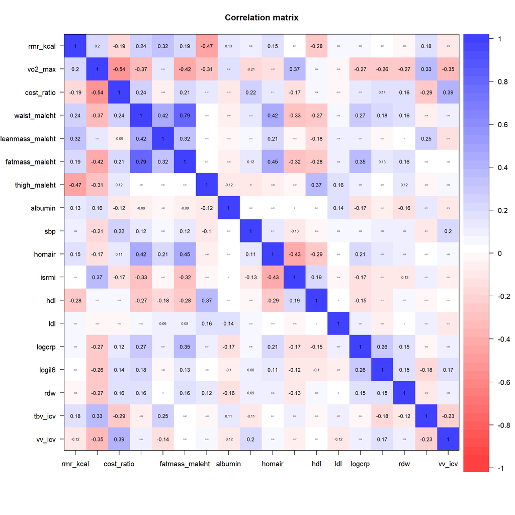

```r
pai = pai %>%
      rename(E1 = rmr_kcal,
             E2 = vo2_max,
             E3 = cost_ratio,
             C1 = waist_maleht,
             C2 = leanmass_maleht,
             C3 = fatmass_maleht,
             C4 = thigh_maleht,
             H1 = albumin,
             H2 = sbp,
             H3 = homair,
             H5 = isrmi,
             H8 = hdl,
             H9 = ldl,
             H10 = logil6,
             H11 = logcrp,
             H12 = rdw,
             B1 = tbv_icv,
             B2 = vv_icv)
```

- Look at the diagnol, what do you think?
- The blocks are interesting!
- Energetics vs waist
- Body Composition: thigh area.
- Albumin. interesting. “other factor?”
- Prob not surprising? -> SBP, LDL -> HDL prob. more informative than LDL

## N number calculation when no. of NA changes.

| Maximal number of missing values per person allowed | n number | Note |
| --- | --- | --- |
| 4 (i.e. < 5) | 1054 |  |
| 3 (i.e. < 5) | 947 |  |
| 2 (i.e. < 5) | 771 |  |
| 1 (i.e. < 5) | 538 |  |
| 0 (i.e. < 5) | 147 | Full complete cases |

## Single Factor Analysis

- In other words, we haven’t put our conceptual domains into this analysis yet.

```r
# View the results
EFA_model
```

```
## Factor Analysis using method =  minres
## Call: fa(r = pai)
## Standardized loadings (pattern matrix) based upon correlation matrix
##       MR1     h2   u2 com
## E1   0.09 0.0077 0.99   1
## E2  -0.62 0.3851 0.61   1
## E3   0.41 0.1694 0.83   1
## C1   0.78 0.6074 0.39   1
## C2   0.22 0.0474 0.95   1
## C3   0.78 0.6038 0.40   1
## C4   0.05 0.0029 1.00   1
## H1  -0.17 0.0282 0.97   1
## H2   0.24 0.0578 0.94   1
## H3   0.51 0.2622 0.74   1
## H5  -0.48 0.2331 0.77   1
## H8  -0.28 0.0767 0.92   1
## H9   0.04 0.0014 1.00   1
## H11  0.42 0.1754 0.82   1
## H10  0.30 0.0924 0.91   1
## H12  0.27 0.0742 0.93   1
## B1  -0.18 0.0335 0.97   1
## B2   0.24 0.0571 0.94   1
##
##                 MR1
## SS loadings    2.92
## Proportion Var 0.16
##
## Mean item complexity =  1
## Test of the hypothesis that 1 factor is sufficient.
##
## The degrees of freedom for the null model are  153  and the objective function was  4.58 with Chi Square of  4788.47
## The degrees of freedom for the model are 135  and the objective function was  2.57
##
## The root mean square of the residuals (RMSR) is  0.12
## The df corrected root mean square of the residuals is  0.13
##
## The harmonic number of observations is  787 with the empirical chi square  3544.55  with prob <  0
## The total number of observations was  1054  with Likelihood Chi Square =  2691.06  with prob <  0
##
## Tucker Lewis Index of factoring reliability =  0.375
## RMSEA index =  0.135  and the 90 % confidence intervals are  0.13 0.139
## BIC =  1751.42
## Fit based upon off diagonal values = 0.63
## Measures of factor score adequacy
##                                                    MR1
## Correlation of (regression) scores with factors   0.92
## Multiple R square of scores with factors          0.84
## Minimum correlation of possible factor scores     0.68
```

```r
# View the factor loadings
EFA_model$loadings
```

```
##
## Loadings:
##     MR1
## E1
## E2  -0.621
## E3   0.412
## C1   0.779
## C2   0.218
## C3   0.777
## C4
## H1  -0.168
## H2   0.240
## H3   0.512
## H5  -0.483
## H8  -0.277
## H9
## H11  0.419
## H10  0.304
## H12  0.272
## B1  -0.183
## B2   0.239
##
##                  MR1
## SS loadings    2.916
## Proportion Var 0.162
```

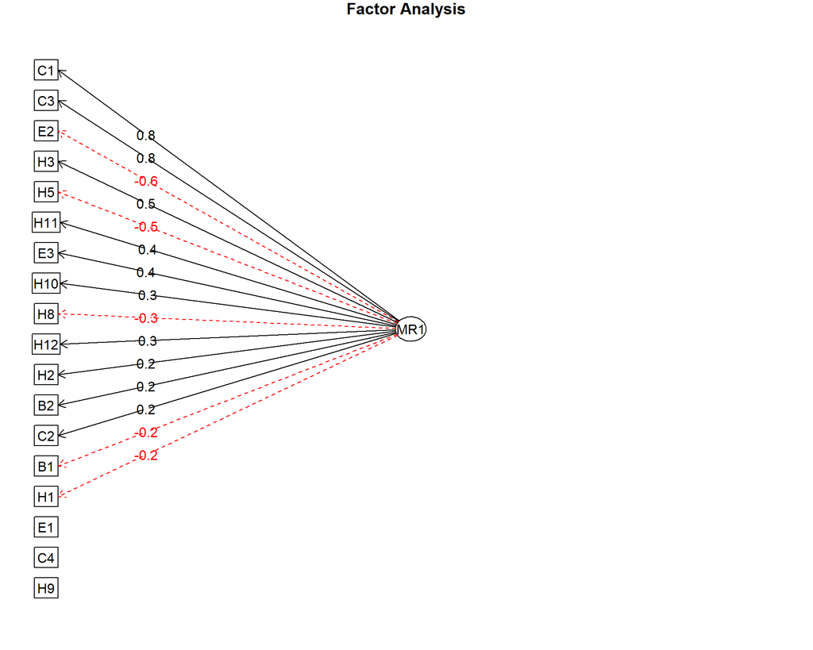

```r
# Create a path diagram of the items' factor loadings
fa.diagram(EFA_model,cut = 0.1)
```

- C4 = thigh_maleht, E1 = rmr_kcal, H9 = ldl

```r
alpha(pai,check.keys = TRUE)
```

```
##
## Reliability analysis
## Call: alpha(x = pai, check.keys = TRUE)
##
##   raw_alpha std.alpha G6(smc) average_r S/N   ase mean  sd median_r
##       0.23      0.69    0.76      0.11 2.2 0.017 3485 883      0.1
##
##  lower alpha upper     95% confidence boundaries
## 0.19 0.23 0.26
##
##  Reliability if an item is dropped:
##     raw_alpha std.alpha G6(smc) average_r S/N alpha se var.r med.r
## E1      0.218      0.70    0.76     0.122 2.4    0.017 0.024 0.112
## E2-     0.228      0.64    0.71     0.095 1.8    0.017 0.024 0.089
## E3      0.228      0.66    0.74     0.104 2.0    0.017 0.026 0.089
## C1      0.227      0.63    0.70     0.091 1.7    0.017 0.023 0.090
## C2      0.017      0.68    0.75     0.113 2.2    0.012 0.026 0.112
## C3      0.027      0.63    0.71     0.093 1.7    0.021 0.023 0.089
## C4      0.234      0.70    0.76     0.122 2.4    0.015 0.024 0.112
## H1-     0.228      0.69    0.76     0.114 2.2    0.017 0.029 0.108
## H2      0.228      0.68    0.76     0.110 2.1    0.017 0.029 0.106
## H3      0.228      0.66    0.74     0.101 1.9    0.017 0.027 0.092
## H5-     0.228      0.66    0.74     0.103 2.0    0.017 0.028 0.094
## H8-     0.227      0.68    0.75     0.112 2.1    0.017 0.027 0.108
## H9      0.227      0.70    0.77     0.120 2.3    0.017 0.028 0.116
## H11     0.228      0.66    0.74     0.103 1.9    0.017 0.029 0.093
## H10     0.228      0.67    0.75     0.108 2.0    0.017 0.029 0.090
## H12     0.228      0.68    0.75     0.109 2.1    0.017 0.029 0.094
## B1-     0.229      0.69    0.76     0.114 2.2    0.017 0.027 0.109
## B2      0.228      0.68    0.75     0.110 2.1    0.017 0.027 0.110
##
##  Item statistics
##        n  raw.r std.r r.cor  r.drop     mean      sd
## E1   986  0.172  0.14 0.056  0.2025  1.3e+03  372.54
## E2-  443  0.280  0.65 0.678  0.3247  1.6e+04    5.78
## E3   801  0.069  0.47 0.440  0.1399  5.4e-01    0.18
## C1  1050  0.597  0.71 0.772  0.7870 -1.3e+00   10.94
## C2  1050  0.561  0.30 0.237  0.3267  6.6e+01 4805.86
## C3  1050  0.772  0.69 0.744  0.3149 -1.7e+02 9636.00
## C4  1050  0.124  0.14 0.071  0.0012 -1.0e+04 1995.35
## H1- 1054  0.055  0.28 0.180  0.0994  1.6e+04    0.37
## H2  1049  0.070  0.35 0.263  0.0936  1.1e+02   14.78
## H3   958  0.344  0.52 0.495  0.4258  2.2e+00    1.85
## H5-  958  0.253  0.49 0.441  0.2652  1.6e+04    7.23
## H8- 1054  0.221  0.32 0.253  0.2373  1.6e+04   17.16
## H9  1052  0.127  0.16 0.038  0.1241  1.0e+02   31.51
## H11 1054  0.264  0.49 0.441  0.3179  1.0e+00    0.72
## H10 1054  0.055  0.40 0.329  0.0937  1.6e+00    0.35
## H12 1054  0.073  0.38 0.287  0.1419  1.4e+01    0.97
## B1-  721 -0.093  0.29 0.209 -0.1033  1.6e+04   55.71
## B2   721 -0.044  0.35 0.287 -0.0348 -1.7e+00   21.55
```

```r
# Calculate the correlation matrix first
pai_cor <- cor(pai, use = "pairwise.complete.obs")

# Then use the correlation matrix to calculate eigenvalues
eigenvals <- eigen(pai_cor)

# Look at the eigenvalues returned
eigenvals$values
```

```
##  [1] 3.5587083 2.5739178 1.5330054 1.1976981 1.0581085 0.9982552 0.9060462
##  [8] 0.8510961 0.8093335 0.7278991 0.6842812 0.6114502 0.5912278 0.5381945
## [15] 0.4992081 0.4241988 0.2698976 0.1674737
```

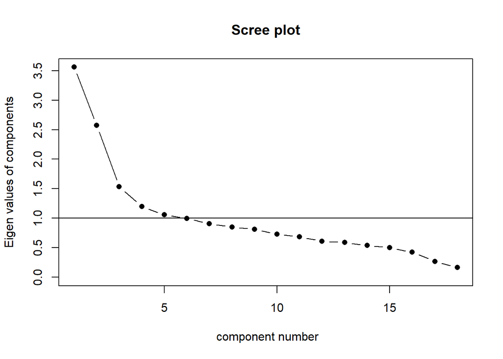

```r
# Then use the correlation matrix to create the scree plot
scree(pai_cor, factors = FALSE)
```

## Multidimensional Factor Analysis [Round 1.] - set up

- Split data into two datasets: (1) one for exploratory purpose. (2) the other for confirmatory purpose
- In the exploratory dataset, we may need *5* factors (“domains”).

## Multidimensional Factor Analysis [Round 1.] - EFA + CFA

- Plan: Conducting a multidimensional EFA  
  Now that we’ve examined the eigenvalues and scree plot to find the data-driven recommended number of factors, we can get down to actually running the multidimensional EFA.
- Technical Note:  
  To run a multidimensional EFA, we need to use the nfactors argument to specify the number of factors desired.
- Disclaimer:  
  Be careful here about the warnings.

```r
# Run the EFA with five factors (as indicated by our scree plot)
EFA_model <- fa(pai_EFA, nfactors = 5)
```

```
## Warning in fac(r = r, nfactors = nfactors, n.obs = n.obs, rotate =
## rotate, : A loading greater than abs(1) was detected. Examine the loadings
## carefully.
```

```
## The estimated weights for the factor scores are probably incorrect.  Try a different factor extraction method.
```

```r
EFA_model
```

```
## Factor Analysis using method =  minres
## Call: fa(r = pai_EFA, nfactors = 5)
##
##  Warning: A Heywood case was detected.
## Standardized loadings (pattern matrix) based upon correlation matrix
##       MR1   MR2   MR3   MR4   MR5    h2      u2 com
## E1   0.41 -0.19 -0.40  0.10 -0.11 0.423 0.57685 2.7
## E2  -0.15 -0.53 -0.16  0.09 -0.30 0.707 0.29326 2.0
## E3   0.08  0.81  0.01 -0.01 -0.09 0.622 0.37821 1.0
## C1   0.84  0.10  0.02 -0.02  0.05 0.764 0.23596 1.0
## C2   0.61 -0.14  0.04  0.03 -0.27 0.425 0.57479 1.5
## C3   0.81  0.05  0.04 -0.04  0.11 0.734 0.26610 1.1
## C4   0.04 -0.02  1.01  0.01 -0.01 0.999 0.00088 1.0
## H1  -0.05 -0.10 -0.06 -0.08 -0.22 0.090 0.91021 2.0
## H2   0.04  0.32 -0.14 -0.05  0.02 0.123 0.87666 1.5
## H3   0.38  0.08 -0.09 -0.29 -0.08 0.303 0.69696 2.2
## H5   0.01  0.02  0.01  1.01  0.01 0.996 0.00438 1.0
## H8  -0.33  0.03  0.36  0.09 -0.09 0.274 0.72572 2.3
## H9   0.17 -0.22  0.14 -0.03  0.12 0.075 0.92538 3.4
## H11  0.28 -0.08  0.01 -0.01  0.45 0.290 0.71043 1.8
## H10  0.04  0.02 -0.08 -0.03  0.44 0.208 0.79194 1.1
## H12  0.11  0.08  0.09 -0.04  0.25 0.139 0.86149 1.9
## B1   0.17 -0.28 -0.01  0.05 -0.25 0.223 0.77717 2.8
## B2  -0.11  0.59 -0.11  0.11  0.05 0.338 0.66244 1.2
##
##                        MR1  MR2  MR3  MR4  MR5
## SS loadings           2.40 1.73 1.43 1.22 0.95
## Proportion Var        0.13 0.10 0.08 0.07 0.05
## Cumulative Var        0.13 0.23 0.31 0.38 0.43
## Proportion Explained  0.31 0.22 0.18 0.16 0.12
## Cumulative Proportion 0.31 0.53 0.72 0.88 1.00
##
##  With factor correlations of
##       MR1   MR2   MR3   MR4   MR5
## MR1  1.00  0.14 -0.01 -0.25  0.14
## MR2  0.14  1.00  0.23 -0.21  0.46
## MR3 -0.01  0.23  1.00 -0.04  0.17
## MR4 -0.25 -0.21 -0.04  1.00 -0.23
## MR5  0.14  0.46  0.17 -0.23  1.00
##
## Mean item complexity =  1.7
## Test of the hypothesis that 5 factors are sufficient.
##
## The degrees of freedom for the null model are  153  and the objective function was  4.8 with Chi Square of  2489.68
## The degrees of freedom for the model are 73  and the objective function was  0.51
##
## The root mean square of the residuals (RMSR) is  0.03
## The df corrected root mean square of the residuals is  0.05
##
## The harmonic number of observations is  393 with the empirical chi square  127.44  with prob <  8.4e-05
## The total number of observations was  527  with Likelihood Chi Square =  265.21  with prob <  1.3e-23
##
## Tucker Lewis Index of factoring reliability =  0.826
## RMSEA index =  0.072  and the 90 % confidence intervals are  0.062 0.08
## BIC =  -192.3
## Fit based upon off diagonal values = 0.97
```

- Try different rotation marix (rotate = “promax”)

```r
EFA_model <- fa(pai_EFA, nfactors = 5, rotate = "promax")
# View results from the model object
EFA_model
```

```
## Factor Analysis using method =  minres
## Call: fa(r = pai_EFA, nfactors = 5, rotate = "promax")
##
##  Warning: A Heywood case was detected.
## Standardized loadings (pattern matrix) based upon correlation matrix
##       MR3   MR2   MR1   MR4   MR5    h2      u2 com
## E1   0.34 -0.45 -0.10  0.15 -0.05 0.423 0.57685 2.2
## E2  -0.17 -0.22 -0.49  0.08 -0.33 0.707 0.29326 2.6
## E3   0.25  0.17  0.81  0.00 -0.11 0.622 0.37821 1.3
## C1   0.84  0.02  0.19  0.05  0.14 0.764 0.23596 1.2
## C2   0.69  0.05 -0.03  0.08 -0.25 0.425 0.57479 1.3
## C3   0.79  0.02  0.13  0.03  0.21 0.734 0.26610 1.2
## C4   0.24  1.05 -0.04 -0.01 -0.08 0.999 0.00088 1.1
## H1  -0.01 -0.04 -0.08 -0.10 -0.26 0.090 0.91021 1.6
## H2   0.06 -0.10  0.32 -0.04  0.03 0.123 0.87666 1.3
## H3   0.39 -0.06  0.11 -0.28 -0.07 0.303 0.69696 2.1
## H5   0.06 -0.05  0.10  1.07  0.09 0.996 0.00438 1.0
## H8  -0.22  0.40 -0.01  0.06 -0.15 0.274 0.72572 2.0
## H9   0.12  0.09 -0.21 -0.03  0.14 0.075 0.92538 2.9
## H11  0.12 -0.08 -0.10  0.02  0.55 0.290 0.71043 1.2
## H10 -0.11 -0.15 -0.02 -0.02  0.51 0.208 0.79194 1.3
## H12  0.06  0.07  0.06 -0.03  0.29 0.139 0.86149 1.3
## B1   0.20 -0.03 -0.22  0.06 -0.27 0.223 0.77717 3.0
## B2  -0.04 -0.02  0.57  0.12  0.06 0.338 0.66244 1.1
##
##                        MR3  MR2  MR1  MR4  MR5
## SS loadings           2.25 1.56 1.56 1.21 1.14
## Proportion Var        0.13 0.09 0.09 0.07 0.06
## Cumulative Var        0.13 0.21 0.30 0.37 0.43
## Proportion Explained  0.29 0.20 0.20 0.16 0.15
## Cumulative Proportion 0.29 0.49 0.70 0.85 1.00
##
##  With factor correlations of
##       MR3   MR2   MR1   MR4   MR5
## MR3  1.00 -0.21 -0.13 -0.34  0.26
## MR2 -0.21  1.00  0.15  0.04  0.29
## MR1 -0.13  0.15  1.00 -0.27  0.47
## MR4 -0.34  0.04 -0.27  1.00 -0.41
## MR5  0.26  0.29  0.47 -0.41  1.00
##
## Mean item complexity =  1.7
## Test of the hypothesis that 5 factors are sufficient.
##
## The degrees of freedom for the null model are  153  and the objective function was  4.8 with Chi Square of  2489.68
## The degrees of freedom for the model are 73  and the objective function was  0.51
##
## The root mean square of the residuals (RMSR) is  0.03
## The df corrected root mean square of the residuals is  0.05
##
## The harmonic number of observations is  393 with the empirical chi square  127.44  with prob <  8.4e-05
## The total number of observations was  527  with Likelihood Chi Square =  265.21  with prob <  1.3e-23
##
## Tucker Lewis Index of factoring reliability =  0.826
## RMSEA index =  0.072  and the 90 % confidence intervals are  0.062 0.08
## BIC =  -192.3
## Fit based upon off diagonal values = 0.97
## Measures of factor score adequacy
##                                                    MR3  MR2  MR1  MR4  MR5
## Correlation of (regression) scores with factors   0.93 1.00 0.89 1.00 0.85
## Multiple R square of scores with factors          0.86 0.99 0.79 0.99 0.71
## Minimum correlation of possible factor scores     0.72 0.99 0.57 0.99 0.43
```

- Interpreting the results  
  As we paln, we’ll be interested in items’ factor loadings and individuals’ factor scores. These will be interpreted in the same way, but since now our EFA is multidimensional, we’ll get results for each factor.
- Note:
1. An item’s loadings represent the amount of information it provides for each factor. Items’ meaningful loadings will be displayed in the output.
2. We’ll notice that many items load onto more than one factor, which means they provide information about multiple factors. This may not be desirable for measure development, so sometimes we may consider only the strongest loading for each item.
3. Each participant will have a factor score for each factor, so that the matrix won’t include blanks. However, participants with missing data will receive NA scores on all factors.
- Now, take a look at the loadings:

```r
# Run the EFA with five factors (as indicated by our scree plot)
EFA_model <- fa(pai_EFA, nfactors = 5)
```

```
## The estimated weights for the factor scores are probably incorrect.  Try a different factor extraction method.
```

```r
# View items' factor loadings
EFA_model$loadings
```

```
##
## Loadings:
##     MR1    MR2    MR3    MR4    MR5
## E1   0.407 -0.190 -0.402  0.104 -0.114
## E2  -0.147 -0.535 -0.156        -0.298
## E3          0.807
## C1   0.837
## C2   0.614 -0.136               -0.275
## C3   0.808                       0.112
## C4                 1.005
## H1                              -0.224
## H2          0.321 -0.144
## H3   0.384               -0.294
## H5                        1.005
## H8  -0.332         0.362
## H9   0.170 -0.215  0.138         0.117
## H11  0.282                       0.452
## H10                              0.437
## H12  0.107                       0.252
## B1   0.171 -0.277               -0.254
## B2  -0.107  0.589 -0.107  0.106
##
##                  MR1   MR2   MR3   MR4   MR5
## SS loadings    2.348 1.607 1.410 1.156 0.805
## Proportion Var 0.130 0.089 0.078 0.064 0.045
## Cumulative Var 0.130 0.220 0.298 0.362 0.407
```

- Take a look at the loadings (rotate = “promax”)

```r
# Run the EFA with five factors (as indicated by our scree plot)
EFA_model <- fa(pai_EFA, nfactors = 5, rotate = "promax")
# View items' factor loadings
EFA_model$loadings
```

```
##
## Loadings:
##     MR3    MR2    MR1    MR4    MR5
## E1   0.336 -0.451 -0.103  0.147
## E2  -0.171 -0.219 -0.495        -0.333
## E3   0.249  0.166  0.810        -0.106
## C1   0.838         0.185         0.145
## C2   0.687                      -0.249
## C3   0.785         0.131         0.207
## C4   0.236  1.053
## H1                              -0.263
## H2                 0.319
## H3   0.387         0.105 -0.281
## H5                 0.103  1.074
## H8  -0.223  0.396               -0.152
## H9   0.120        -0.213         0.141
## H11  0.123        -0.103         0.547
## H10 -0.114 -0.145                0.507
## H12                              0.290
## B1   0.203        -0.218        -0.265
## B2                 0.572  0.115
##
##                  MR3   MR2   MR1   MR4   MR5
## SS loadings    2.347 1.607 1.530 1.305 1.097
## Proportion Var 0.130 0.089 0.085 0.073 0.061
## Cumulative Var 0.130 0.220 0.305 0.377 0.438
```

- View the first few lines of participants’ factor scores

```r
head(EFA_model$scores)
```

```
##             MR3        MR2        MR1        MR4        MR5
## 70           NA         NA         NA         NA         NA
## 415 -0.68702295 -0.3064290 0.31887635 -0.6169276 -0.5234075
## 538          NA         NA         NA         NA         NA
## 264 -0.01283813 -0.9334778 0.02598091 -0.4362228  0.1441829
## 335          NA         NA         NA         NA         NA
## 478          NA         NA         NA         NA         NA
```

```r
# Run each theorized EFA on our dataset
pai_theory <- fa(pai_EFA, nfactors = 4)
pai_eigen <- fa(pai_EFA, nfactors = 5)

# Compare the BIC values
pai_theory$BIC
```

```
## [1] -219.7156
```

```r
pai_eigen$BIC
```

```
## [1] -192.2999
```

- Here, it seems like our four-domain function better, but this may be by chance.
- Technical note:
1. Warning in fac(r = r, nfactors = nfactors, n.obs = n.obs, rotate = rotate, : A loading greater than abs(1) was detected. Examine the loadings carefully.
2. The estimated weights for the factor scores are probably incorrect. Try a different factor extraction method.
3. Warning in fac(r = r, nfactors = nfactors, n.obs = n.obs, rotate = rotate, : An ultra-Heywood case was detected. Examine the results carefully
2. Perform the analysis in the confirmatory dataset. Here, we have computational difficulty (singular).  
   Different optimizers have been tried, but none of them works.
- Questions:
1. Do we want to limit to a certain popultion? (ex: based on age? # of diseases?)
2. Appropriateness to use “weight-adjusted lean mass/fat mass”?
3. Appropriateness to use “ICV-adjusted brain volume”?
4. More specifically, should we use the residual from regressing brain volume on ICV as “ICV-adjusted brain volume”?
5. Should it be gender-specific?
6. Try to solve technical questions with Michelle after then.

# Progress

## Fitbit data

- 60 ppl.
- Further look

## Summarizing the longitudinal results.

## Keep reading BLSA whitebook

Exerpted Readings: Physilogical Indices of Aging (Jordan D. TObin, 1981)  
James J.Schlesselman had published papers about study design for BLSA, including [sample size determination](https://www.sciencedirect.com/science/article/pii/002196817390060X) and frequency of measurement and study duration

Several questions:  
* Study design documentation?  
* Much better coverage  
* 60th year? [50 year plan for future, by Dr. Ferrucci](https://www.ncbi.nlm.nih.gov/pubmed/19126858)

## Short critiques/comparisons of current models

## Others

- glucolycis

# Morgan’s PLOS Medicine

- MAPS?